# Ник и Ярослав: сборки, дыхание и пульсовые сигналы Scorpion

**Сессия 22 октября 2026 года. Самостоятельный исследовательский отчёт.**

Цель — установить, как размер продольной боковой сборки и вариант ТТРКГ связаны с общим импедансом и формой пульсового сигнала у каждого участника. Для этого сначала проверяются записи и подключения, затем сравниваются задержки на глубоком вдохе и выдохе, четыре последовательных сердечных цикла и условные решения двуслойной модели бокового монтажа. Отдельные пробы с отключением и перестановкой пар позволяют проверить сопоставимость измерений. Ник и Ярослав — псевдонимы участников.

**Доказательный статус.** Приборные поля и результаты файловых проверок отделены от авторских сведений, реконструкции дыхания и математических расчётов. Дыхательные границы и автоматические QRS здесь кандидатные: их ручное принятие не выполнено. Все расчёты по этим окнам являются исследовательскими. Значения функций сердца не определяются.

В архиве есть 8 TXT Ника и 7 TXT Ярослава. Основной размерный ряд — 140, 100 и 60 мм при ТТРКГ 2×2. Отдельная пара записей сравнивает ТТРКГ 2×2 и 1×1 при боковой 60 мм. Монтажей 1×4, ТЕПС, АЕПС, крестов, размеров 80 и 120 мм в этой сессии нет.

Все таблицы раскрываются по нажатию. На узком экране графики прокручиваются горизонтально. На графиках используются названия электродных сборок. Техническое соответствие полям прибора приведено в разделе происхождения данных.

## 1. Что зарегистрировано и откуда известен монтаж

Назначение размеров и вариантов, общий центр продольных боковых сборок, постоянство подключения внутри каждого участника и порядок обычных дыхательных проб подтверждены автором. Зондирование — 100 кГц; ток около 7000 мкА на каждый источник. Не установлено, относится ли указанная величина к амплитуде или действующему значению. Токи и электрические фазы источников отдельно в этой обработке не измерялись.

У Ника ТТРКГ соответствует первому импедансному и ЭКГ-полю, боковая — второму; у Ярослава соответствие обратное. Это вывод из проб одной подключённой сборки и изменения ЭКГ при её отключении. Автор подтвердил неизменность соответствия внутри каждого участника. Одной амплитуды ЭКГ для такого вывода недостаточно: в некоторых записях боковое отведение больше ТТРКГ или содержит сильную помеху.

На руках в 2×2 используются верхние и нижние контакты; в 1×1 — только верхние. Измерительная группа расположена примерно в 20 мм от плеча, токовая — примерно в 100 мм от измерительной. Обхват Ника 370 мм сообщён автором; для Ярослава та же величина приблизительна, погрешность не задана. Цилиндрический радиус при таком обхвате равен 370/(2π) ≈ 58,89 мм. Боковая область — справа над рёбрами. Эти сведения задают схему установки, но сами по себе не задают индивидуальные координаты центра на КТ.

При пробах отключения разъём вынимался из прибора, электроды оставались на теле. В проверке взаимности у Ника переставляли токовую и измерительную пары **ТТРКГ**. Это подтверждённые сведения автора.

**Таблица 1. Полный состав новой сессии; идентификаторы закреплены за исходными файлами**

| Участник | Запись | Сборки | TXT | Отсчётов | Длительность при 1000 Гц, с |
| --- | --- | --- | --- | --- | --- |
| Ник | SCV2-N-001 | Боковая 140 мм + ТТРКГ 2×2 | оба канала 140 2х2.txt | 60994 | 60.993 |
| Ник | SCV2-N-002 | Только ТТРКГ 2×2 | только ттркг 2х2.txt | 61199 | 61.198 |
| Ник | SCV2-N-003 | Только боковая 140 мм | только 140.txt | 64596 | 64.595 |
| Ник | SCV2-N-004 | Попеременное отключение: 140 мм и ТТРКГ 2×2 | попеременное откключение каналов 140 2х2.txt | 117825 | 117.82 |
| Ник | SCV2-N-005 | Боковая 100 мм + ТТРКГ 2×2 | оба канала 100 2х2.txt | 62055 | 62.054 |
| Ник | SCV2-N-006 | Боковая 60 мм + ТТРКГ 2×2 | оба канала 60 2х2.txt | 64551 | 64.55 |
| Ник | SCV2-N-007 | Боковая 60 мм + ТТРКГ 1×1 | оба канала 60 1х1.txt | 61097 | 61.096 |
| Ник | SCV2-N-008 | Боковая 60 мм + ТТРКГ 1×1 · переставлены пары ТТРКГ | оба канала 60 1х1 проыерка взаимности.txt | 63673 | 63.672 |
| Ярослав | SCV2-Y-001 | Боковая 140 мм + ТТРКГ 2×2 | оба канала 140 2х2.txt | 72105 | 72.104 |
| Ярослав | SCV2-Y-002 | Только ТТРКГ 2×2 | Только ттркг 2х2.txt | 75853 | 75.852 |
| Ярослав | SCV2-Y-003 | Только боковая 140 мм | только 140.txt | 65489 | 65.488 |
| Ярослав | SCV2-Y-004 | Попеременное отключение: 140 мм и ТТРКГ 2×2 | попеременное отключение каналов 140 2х2.txt | 94566 | 94.565 |
| Ярослав | SCV2-Y-005 | Боковая 100 мм + ТТРКГ 2×2 | оба канала 100 2х2.txt | 65463 | 65.462 |
| Ярослав | SCV2-Y-006 | Боковая 60 мм + ТТРКГ 2×2 | оба канала 60 2х2.txt | 66449 | 66.448 |
| Ярослав | SCV2-Y-007 | Боковая 60 мм + ТТРКГ 1×1 | оба канала 60 1х1.txt | 65512 | 65.511 |

Времена изменения файлов отражают экспорт, а не измеренные команды. TXT прочитаны как 11 полей с десятичной запятой и пустым полем в конце строки. Проверены контрольные суммы, конечность всех чисел и приращения циклического COUNT. Дубликатов TXT по байтам нет; разрывов последовательности COUNT по модулю 256 не обнаружено. Это техническая проверка, которая не исключает потерю целого числа периодов счётчика и не подтверждает качество физиологии.

Все 15 TXT сопоставлены с одним длинным BIN **на всей длине**, по COUNT и обоим ЭКГ-полям с точностью округления экспорта. Папка BIN названа именем другого участника; принадлежность участков установлена по содержимому TXT. Во всех связанных участках одинаковы поля настроек: 1000 и пара [100000000, 7000]. Рабочая трактовка первого поля как периода 1000 мкс даёт 1000 отсчётов/с и согласуется с формой ЭКГ. Единицы двоичного протокола производителем не подтверждены; контрольная сумма пакетов отдельно не проверена. Малый BIN не содержит найденного полного совпадения с этими TXT.

## 2. Как из записей получены окна и пульсовые кривые

Дыхательная последовательность обычных проб: спокойное дыхание → задержка на глубоком вдохе → усиленное дыхание → задержка на глубоком выдохе. Временных меток команд нет. Для каждой записи отдельно просмотрены медленные составляющие двух импедансных полей; сохранены три диапазона неоднозначных переходов. Внутренние окна начинаются через 2 с после поздней границы перехода и заканчиваются за 2 с до ранней границы следующего перехода. Последние 5 с записи исключаются. При короткой задержке остаётся мало данных; такой недостаток не восполняется переносом границ другой записи.

Общий импеданс разложен на медленную составляющую ниже 0,5 Гц, пульсовую полосу 0,7–12 Гц и остаток. Применены фильтры Баттерворта четвёртого порядка с прямым и обратным проходом по целой записи и дополнением краёв 5 с. Основные уровни — **медианы исходного общего импеданса** во внутренних окнах. Пульсовая кривая — только выбранная частотная полоса; это не доказанное разделение тканевых источников.

Для ЭКГ подавлены 50, 100 и 150 Гц с Q=30, затем оставлена полоса 0,5–40 Гц; края дополнены на 3 с. Сохранён вариант подавления только 50 Гц для диагностики влияния фильтра. Энергетический детектор 5–25 Гц создаёт кандидаты QRS. При расстоянии менее 450 мс сохранён более сильный экстремум фильтрованной ЭКГ; исходные кандидаты тоже сохранены. Это устраняет часть слабых лишних событий, но ограничивает анализ ритмом реже 133 событий/мин и не заменяет ручное принятие R-зубцов.

На вдохе выбираются пять последовательных кандидатов, ограничивающих четыре интервала 0,45–1,8 с, ближе всего к середине внутреннего окна. Амплитуда импедансного пульса в выборе не участвует. При сравнении начало первого QRS совмещено с нулём; время и амплитуда четырёх циклов не нормированы. Для медианного цикла каждый полный интервал QRS–QRS отдельно приведён к 200 фазовым точкам, из него вычтено собственное среднее, затем взята медиана по циклам. Межзаписное совмещение по ЭКГ не делает записи одновременными.

**Таблица 2. Внутренние кандидатные окна и диагностика ЭКГ; это не ручное принятие разметки**

| Запись | Сборки | Вдох, с | Выдох, с | Четыре цикла на вдохе, с | Исходных QRS | После отбора | Различие вариантов фильтра ЭКГ, мВ RMS |
| --- | --- | --- | --- | --- | --- | --- | --- |
| SCV2-N-001 | Боковая 140 мм + ТТРКГ 2×2 | [21.0, 32.0] | [55.0, 55.994] | [24.45, 28.168] | 76 | 70 | 1.5053e-05 |
| SCV2-N-002 | Только ТТРКГ 2×2 | [19.0, 26.0] | [53.0, 56.199] | [21.158, 24.57] | 84 | 76 | 2.3628e-05 |
| SCV2-N-003 | Только боковая 140 мм | [21.0, 27.0] | [51.0, 59.596] | [22.216, 25.497] | 78 | 77 | 8.2452e-06 |
| SCV2-N-004 | Попеременное отключение: 140 мм и ТТРКГ 2×2 | [] | [] | Дыхательные циклы не выбирались | 0 | 0 | 0.00029749 |
| SCV2-N-005 | Боковая 100 мм + ТТРКГ 2×2 | [21.0, 29.0] | [53.0, 57.055] | [23.682, 26.906] | 84 | 73 | 2.5736e-05 |
| SCV2-N-006 | Боковая 60 мм + ТТРКГ 2×2 | [20.0, 25.0] | [53.0, 59.551] | [20.227, 23.886] | 87 | 80 | 5.3405e-06 |
| SCV2-N-007 | Боковая 60 мм + ТТРКГ 1×1 | [24.0, 31.0] | [55.0, 56.097] | [25.732, 29.152] | 75 | 71 | 4.6915e-05 |
| SCV2-N-008 | Боковая 60 мм + ТТРКГ 1×1 · переставлены пары ТТРКГ | [22.0, 31.0] | [57.0, 58.673] | [24.9, 27.888] | 81 | 78 | 5.2077e-05 |
| SCV2-Y-001 | Боковая 140 мм + ТТРКГ 2×2 | [24.0, 34.0] | [60.0, 67.105] | [26.49, 30.8] | 85 | 77 | 2.2583e-05 |
| SCV2-Y-002 | Только ТТРКГ 2×2 | [30.0, 37.0] | [65.0, 70.853] | [30.948, 35.058] | 83 | 79 | 2.1868e-05 |
| SCV2-Y-003 | Только боковая 140 мм | [21.0, 27.0] | [53.0, 60.489] | [22.92, 25.961] | 81 | 73 | 4.9511e-05 |
| SCV2-Y-004 | Попеременное отключение: 140 мм и ТТРКГ 2×2 | [] | [] | Дыхательные циклы не выбирались | 0 | 0 | 0.0010257 |
| SCV2-Y-005 | Боковая 100 мм + ТТРКГ 2×2 | [22.0, 32.0] | [55.0, 60.463] | [25.374, 29.383] | 78 | 67 | 1.7501e-05 |
| SCV2-Y-006 | Боковая 60 мм + ТТРКГ 2×2 | [22.0, 31.0] | [56.0, 61.449] | [24.776, 29.127] | 85 | 68 | 4.2403e-05 |
| SCV2-Y-007 | Боковая 60 мм + ТТРКГ 1×1 | [23.0, 33.0] | [57.0, 60.512] | [25.894, 29.928] | 81 | 67 | 1.8749e-05 |

Интервал P05–P95 описывает разброс отсчётов внутри выбранного окна; он не является доверительным интервалом медианы. Отсчёты связаны во времени, независимых повторов каждой установки нет. Погрешности размещения, контакта, воспроизведения дыхания и межзаписной физиологии численно не установлены. Поэтому невзвешенная подгонка в Ом далее служит диагностикой модели, без утверждения о нормальном независимом шуме или полной неопределённости найденных сопротивлений.

Для обеих проб попеременного отключения QRS и пульсовые циклы не рассчитываются: скачки соединения вызывают большие выбросы и переходные эффекты фильтров. Рассматриваются исходные импедансные числа на отдельно выбранных участках состояния. Числа отключённого тракта не интерпретируются как физиологический сигнал.

## 3. Ник: размер сборки и дыхательный контраст

Как выглядят целые записи и где находятся выбранные интервалы?

[interactive chart not shown]

**Рисунок 1. Ник. Общий импеданс, ЭКГ и пульсовая полоса с переключением записи.**

Зелёные и синие области обозначают внутренние кандидатные окна вдоха и выдоха. Для отображения длинных кривых сохранены минимумы и максимумы в последовательных коротких блоках, около 2400 точек на кривую. Численные расчёты используют все исходные отсчёты. Пробы отключения показаны без пульсовой интерпретации.

Как меняется абсолютный уровень бокового импеданса с размером и дыханием?

[interactive chart not shown]

**Рисунок 2. Ник. Медианы бокового импеданса на глубоком вдохе и выдохе, Ом.**

Основную размерную зависимость задают три точки при ТТРКГ 2×2. Дополнительная точка 60 мм при ТТРКГ 1×1 относится к отдельному включению. Между размерами меняются время записи, установка и контакт; интервалы не являются повторными измерениями одного и того же физиологического состояния.

Меняется ли ТТРКГ при неизменном варианте контактов и смене боковой сборки?

[interactive chart not shown]

**Рисунок 3. Ник. Медианы ТТРКГ на вдохе и выдохе; по оси X — сопутствующая боковая сборка.**

Точки ТТРКГ 2×2 нельзя читать как размерный ряд самой ТТРКГ: её контакты на руках не перемещались. Различия характеризуют межзаписную изменчивость при смене соседней сборки. При 60 мм есть отдельное сравнение вариантов ТТРКГ.

На вдохе и выдохе боковые уровни составляют соответственно 140 мм — 45.353 и 38.221 Ом; 100 мм — 57.356 и 50.914 Ом; 60 мм — 98.798 и 95.401 Ом. Во всех трёх выбранных парах уровень на вдохе выше. Это экспериментальное наблюдение в пределах реконструированных окон; оно не определяет сопротивление отдельной ткани.

**Таблица 3. Ник: уровни, изменчивость внутри окна и число циклов**

| Сборка | Размер боковой, мм | ТТРКГ | Дыхание | Медиана, Ом | P05–P95 исходных значений, Ом | Изменение между половинами окна, Ом | Полных кандидатных циклов | Размах медианного цикла, мОм |
| --- | --- | --- | --- | --- | --- | --- | --- | --- |
| ТТРКГ | 140 | 2×2 | Глубокий вдох | 57.735 | [57.67113, 57.8448115] | -0.0291 | 11 | 161.02 |
| Боковая сборка | 140 | 2×2 | Глубокий вдох | 45.353 | [45.245039500000004, 45.501079499999996] | -0.11843 | 11 | 133.7 |
| ТТРКГ | 140 | 2×2 | Глубокий выдох | 57.319 | [57.233247, 57.378514] | 0.01222 | 0 | — |
| Боковая сборка | 140 | 2×2 | Глубокий выдох | 38.221 | [38.1947855, 38.2537805] | 0.013115 | 0 | — |
| ТТРКГ | 100 | 2×2 | Глубокий вдох | 58.443 | [58.41051, 58.522141500000004] | -0.0022646 | 9 | 118.24 |
| Боковая сборка | 100 | 2×2 | Глубокий вдох | 57.356 | [57.2037585, 57.57839] | -0.15761 | 9 | 81.343 |
| ТТРКГ | 100 | 2×2 | Глубокий выдох | 57.724 | [57.629597000000004, 57.779705] | 0.020408 | 4 | 142.65 |
| Боковая сборка | 100 | 2×2 | Глубокий выдох | 50.914 | [50.807938, 50.984745] | 0.086622 | 4 | 29.595 |
| ТТРКГ | 60 | 2×2 | Глубокий вдох | 57.722 | [57.6717395, 57.80687] | -0.027228 | 5 | 122.29 |
| Боковая сборка | 60 | 2×2 | Глубокий вдох | 98.798 | [98.54512600000001, 99.068361] | -0.16559 | 5 | 130.93 |
| ТТРКГ | 60 | 2×2 | Глубокий выдох | 56.85 | [56.75173, 56.895765] | 0.026099 | 9 | 130.63 |
| Боковая сборка | 60 | 2×2 | Глубокий выдох | 95.401 | [95.184075, 95.615675] | 0.011993 | 9 | 103.16 |
| ТТРКГ | 60 | 1×1 | Глубокий вдох | 61.625 | [61.5841785, 61.711580999999995] | -0.0025136 | 7 | 134.88 |
| Боковая сборка | 60 | 1×1 | Глубокий вдох | 87.29 | [87.021807, 87.5743555] | -0.093402 | 7 | 153.4 |
| ТТРКГ | 60 | 1×1 | Глубокий выдох | 61.277 | [61.16649, 61.320732] | 0.0045034 | 0 | — |
| Боковая сборка | 60 | 1×1 | Глубокий выдох | 85.178 | [84.92578999999999, 85.438224] | 0.011443 | 0 | — |

Сопоставима ли форма бокового пульса при трёх размерах?

[interactive chart not shown]

**Рисунок 4. Ник. Боковые 140, 100 и 60 мм: по четыре кандидатных цикла на глубоком вдохе.**

Показаны полные отсчёты выбранных участков при 1000 Гц. Нижний график позволяет проверить положение комплексов ЭКГ относительно пульсовой кривой. Привязка к ЭКГ служит временным ориентиром и сама по себе не доказывает сердечное происхождение каждого колебания импеданса.

Как выглядит ТТРКГ в тех же трёх размерных пробах?

[interactive chart not shown]

**Рисунок 5. Ник. ТТРКГ 2×2 при боковых 140, 100 и 60 мм: четыре кандидатных цикла на вдохе.**

Это контроль сопутствующих изменений ТТРКГ при сохранённой схеме на руках. Отдельные записи выровнены только по первому QRS, поэтому различия длительности четырёх циклов сохранены.

Отличаются ли пульсовые кривые двух вариантов ТТРКГ при одинаковой боковой 60 мм?

[interactive chart not shown]

**Рисунок 6. Ник. Отдельное пульсовое сравнение ТТРКГ 1×1 и 2×2 при боковой 60 мм.**

Менялось объединение контактов на руках, а соответствующие позиции сохранялись. Сборки записаны последовательно; амплитуда не подгонялась. Варианта 1×4 в этой сессии нет.

Как сравнить медианную форму, отделив различие длительности циклов?

[interactive chart not shown]

**Рисунок 7. Ник. Медианные кандидатные циклы на вдохе в нормированной фазе QRS–QRS.**

Фаза приведена к общему интервалу только в этом представлении. Размах медианного цикла и медиана размахов отдельных циклов — разные величины; здесь показана первая. Количество включённых циклов приведено в таблице уровней.

## 4. Ярослав: размер сборки и дыхательный контраст

Как выглядят целые записи и где находятся выбранные интервалы?

[interactive chart not shown]

**Рисунок 8. Ярослав. Общий импеданс, ЭКГ и пульсовая полоса с переключением записи.**

Зелёные и синие области обозначают внутренние кандидатные окна вдоха и выдоха. Для отображения длинных кривых сохранены минимумы и максимумы в последовательных коротких блоках, около 2400 точек на кривую. Численные расчёты используют все исходные отсчёты. Пробы отключения показаны без пульсовой интерпретации.

Как меняется абсолютный уровень бокового импеданса с размером и дыханием?

[interactive chart not shown]

**Рисунок 9. Ярослав. Медианы бокового импеданса на глубоком вдохе и выдохе, Ом.**

Основную размерную зависимость задают три точки при ТТРКГ 2×2. Дополнительная точка 60 мм при ТТРКГ 1×1 относится к отдельному включению. Между размерами меняются время записи, установка и контакт; интервалы не являются повторными измерениями одного и того же физиологического состояния.

Меняется ли ТТРКГ при неизменном варианте контактов и смене боковой сборки?

[interactive chart not shown]

**Рисунок 10. Ярослав. Медианы ТТРКГ на вдохе и выдохе; по оси X — сопутствующая боковая сборка.**

Точки ТТРКГ 2×2 нельзя читать как размерный ряд самой ТТРКГ: её контакты на руках не перемещались. Различия характеризуют межзаписную изменчивость при смене соседней сборки. При 60 мм есть отдельное сравнение вариантов ТТРКГ.

На вдохе и выдохе боковые уровни составляют соответственно 140 мм — 36.559 и 26.500 Ом; 100 мм — 50.066 и 41.957 Ом; 60 мм — 55.969 и 49.053 Ом. Во всех трёх выбранных парах уровень на вдохе выше. Это экспериментальное наблюдение в пределах реконструированных окон; оно не определяет сопротивление отдельной ткани.

**Таблица 4. Ярослав: уровни, изменчивость внутри окна и число циклов**

| Сборка | Размер боковой, мм | ТТРКГ | Дыхание | Медиана, Ом | P05–P95 исходных значений, Ом | Изменение между половинами окна, Ом | Полных кандидатных циклов | Размах медианного цикла, мОм |
| --- | --- | --- | --- | --- | --- | --- | --- | --- |
| ТТРКГ | 140 | 2×2 | Глубокий вдох | 48.96 | [48.8849295, 49.0362505] | -0.011645 | 9 | 152.12 |
| Боковая сборка | 140 | 2×2 | Глубокий вдох | 36.559 | [36.461516, 36.63884] | -0.019981 | 9 | 149.55 |
| ТТРКГ | 140 | 2×2 | Глубокий выдох | 48.358 | [48.281528, 48.430666] | -0.017063 | 9 | 148.49 |
| Боковая сборка | 140 | 2×2 | Глубокий выдох | 26.5 | [26.429782, 26.530708] | 0.026702 | 9 | 44.89 |
| ТТРКГ | 100 | 2×2 | Глубокий вдох | 47.759 | [47.684999000000005, 47.846872000000005] | 0.018063 | 9 | 141.74 |
| Боковая сборка | 100 | 2×2 | Глубокий вдох | 50.066 | [49.923079, 50.224050999999996] | -0.14704 | 9 | 156.51 |
| ТТРКГ | 100 | 2×2 | Глубокий выдох | 47.139 | [47.068402999999996, 47.24094] | 0.030541 | 6 | 155.5 |
| Боковая сборка | 100 | 2×2 | Глубокий выдох | 41.957 | [41.902125999999996, 42.017226] | 0.039326 | 6 | 72.605 |
| ТТРКГ | 60 | 2×2 | Глубокий вдох | 47.331 | [47.2473765, 47.41746] | 0.035328 | 7 | 142.61 |
| Боковая сборка | 60 | 2×2 | Глубокий вдох | 55.969 | [55.7877575, 56.180033] | -0.19416 | 7 | 108.04 |
| ТТРКГ | 60 | 2×2 | Глубокий выдох | 47.013 | [46.944131999999996, 47.095064] | -0.0037923 | 6 | 159.23 |
| Боковая сборка | 60 | 2×2 | Глубокий выдох | 49.053 | [48.91809, 49.175298000000005] | 0.10581 | 6 | 56.589 |
| ТТРКГ | 60 | 1×1 | Глубокий вдох | 49.714 | [49.661148499999996, 49.79668] | -0.002149 | 9 | 137.21 |
| Боковая сборка | 60 | 1×1 | Глубокий вдох | 54.071 | [54.0201195, 54.138962] | -0.039494 | 9 | 74.018 |
| ТТРКГ | 60 | 1×1 | Глубокий выдох | 48.998 | [48.9059665, 49.099661499999996] | 0.048652 | 3 | 161.45 |
| Боковая сборка | 60 | 1×1 | Глубокий выдох | 47.2 | [47.009491000000004, 47.3622] | 0.20259 | 3 | 47.455 |

Сопоставима ли форма бокового пульса при трёх размерах?

[interactive chart not shown]

**Рисунок 11. Ярослав. Боковые 140, 100 и 60 мм: по четыре кандидатных цикла на глубоком вдохе.**

Показаны полные отсчёты выбранных участков при 1000 Гц. Нижний график позволяет проверить положение комплексов ЭКГ относительно пульсовой кривой. Привязка к ЭКГ служит временным ориентиром и сама по себе не доказывает сердечное происхождение каждого колебания импеданса.

Как выглядит ТТРКГ в тех же трёх размерных пробах?

[interactive chart not shown]

**Рисунок 12. Ярослав. ТТРКГ 2×2 при боковых 140, 100 и 60 мм: четыре кандидатных цикла на вдохе.**

Это контроль сопутствующих изменений ТТРКГ при сохранённой схеме на руках. Отдельные записи выровнены только по первому QRS, поэтому различия длительности четырёх циклов сохранены.

Отличаются ли пульсовые кривые двух вариантов ТТРКГ при одинаковой боковой 60 мм?

[interactive chart not shown]

**Рисунок 13. Ярослав. Отдельное пульсовое сравнение ТТРКГ 1×1 и 2×2 при боковой 60 мм.**

Менялось объединение контактов на руках, а соответствующие позиции сохранялись. Сборки записаны последовательно; амплитуда не подгонялась. Варианта 1×4 в этой сессии нет.

Как сравнить медианную форму, отделив различие длительности циклов?

[interactive chart not shown]

**Рисунок 14. Ярослав. Медианные кандидатные циклы на вдохе в нормированной фазе QRS–QRS.**

Фаза приведена к общему интервалу только в этом представлении. Размах медианного цикла и медиана размахов отдельных циклов — разные величины; здесь показана первая. Количество включённых циклов приведено в таблице уровней.

## 5. Что дают отключения и перестановка пар

Отключения проверяются внутри одной записи, отдельно от дыхательных размерных сравнений. На выбранных участках сравниваются медианы исходных чисел. Состояние трактов устанавливается по контексту пробы и характерному переходу, а не по перенесённому порогу другого прибора. У отключённого тракта остаются значения около 4,6 или 6,4 Ом; они не являются измерением тела.

Таблица сохраняет также разброс 5–95%: особенно после повторного подключения выбранный участок может оставаться переходным. По уточнению автора оба участника на протяжении всей пробы находились на глубоком вдохе. Это фиксирует предусмотренное состояние дыхания, но не исключает изменение уровня со временем, движение и контактные переходы. Изменения активного тракта пока нельзя однозначно отнести к отключению соседнего; физический механизм не установлен.

**Таблица 5. Выбранные участки попеременного отключения; числа отключённого тракта технические**

| Участник | Состояние | Начало, с | Конец, с | ТТРКГ, Ом | ТТРКГ P05–P95, Ом | Боковая, Ом | Боковая P05–P95, Ом |
| --- | --- | --- | --- | --- | --- | --- | --- |
| Ник | Обе сборки подключены | 5 | 13 | 57.704 | [57.643499500000004, 57.7772505] | 45.739 | [45.6872355, 45.800110499999995] |
| Ник | Только ТТРКГ | 24 | 41 | 57.671 | [57.6314395, 57.754200999999995] | 4.6106 | [4.60838, 5.1297204999999995] |
| Ник | Обе сборки подключены | 55 | 62 | 57.647 | [57.591809500000004, 57.718003] | 45.385 | [45.34346, 45.44685] |
| Ник | Только боковая | 77 | 100 | 6.4203 | [0.01811, 7.2484435000000005] | 45.229 | [45.019695, 45.367913] |
| Ник | Обе сборки подключены | 112 | 116 | 57.731 | [57.025971999999996, 57.842413] | 44.87 | [42.1170955, 44.9581805] |
| Ярослав | Обе сборки подключены | 5 | 11 | 47.26 | [47.047062, 47.4795815] | 30.875 | [30.1271595, 31.615686999999998] |
| Ярослав | Только ТТРКГ | 21 | 32 | 47.505 | [47.4270495, 47.60631] | 6.6921 | [6.41067, 7.8580945] |
| Ярослав | Обе сборки подключены | 41 | 44 | 47.516 | [47.4220075, 47.601062] | 32.026 | [31.888399500000002, 32.1130735] |
| Ярослав | Только боковая | 55 | 65 | 4.6041 | [0.010259500000000001, 5.113408000000001] | 31.891 | [31.769779500000002, 32.0018605] |
| Ярослав | Обе сборки подключены | 78 | 89 | 48.013 | [47.309148, 48.3211015] | 32.226 | [30.7540565, 37.3671655] |

Сохранился ли ответ ТТРКГ Ника после перестановки токовой и измерительной пар?

[interactive chart not shown]

**Рисунок 15. Ник. Обычное и взаимное включение ТТРКГ 1×1 при боковой 60 мм.**

На вдохе медиана ТТРКГ меняется с 61,625 до 61,577 Ом, на выдохе — с 61,277 до 60,951 Ом. На выдохе окна короткие: при обычном включении полных кандидатных циклов нет, после перестановки есть один цикл 57,552–58,192 с. Боковая сборка в обеих пробах подключена, записи последовательные. Поэтому близость уровней не является независимой метрологической проверкой взаимности одного изолированного порта: вклад второго источника и воспроизводимость дыхания не разделены.

## 6. Что позволяет двуслойная модель боковых сборок

Задача этого раздела — проверить, достаточно ли двух однородных слоёв, чтобы описать три размера каждого участника. **ТТРКГ в модель не входит.** Наружный слой имеет эффективные толщину h и сопротивление ρ₁, внутренний — ρ₂. Обе среды изотропны и полубесконечны по боковым направлениям; граница плоская. Это сокращение реальной грудной стенки, кости и лёгкого. Раздельное влияние жира и кости в двух параметрах не определяется.

Прямая модель задаёт только ток боковой сборки. Ток источника ТТРКГ, его фаза, металлические контакты на руках и их электрические объединения в этом сокращении не моделируются. В основные записи входят оба подключённых монтажа; допустимость такого сокращения ещё требует проверки по совместной пространственной модели. Невязка может включать влияние сопутствующего монтажа, поэтому даже хороший подбор не устанавливает сопротивление конкретной ткани.

Для номинального размера L центры A–M–N–B заданы как −L/2, −L/4, L/4, L/2. Все четыре контакта — диски диаметром 5 мм. Это явный геометрический сценарий, а не измеренный в новой сессии диаметр. По токовому диску задан равномерный ток, напряжение усредняется по измерительному диску. Контактный импеданс и эквипотенциальная металлическая площадка в этой аналитической модели отсутствуют.

Используется ряд изображений для двух слоёв. Для каждой пары площадок усредняется функция

$$G(r)=\frac{\rho_1}{2\pi}\left[\frac{1}{r}+ 2\sum_{n=1}^{256}\frac{k^n}{\sqrt{r^2+(2nh)^2}}\right],\qquad k=\frac{\rho_2-\rho_1}{\rho_2+\rho_1}.\tag{1}$$

Длины в формуле (1) выражены в метрах, ρ — в Ом·м; комбинация потенциалов для A–M–N–B даёт передаточный импеданс в Ом. Интегрирование по каждому диску использует 4 радиальных узла и 16 углов. В однородном пределе k=0 остаётся поверхностная функция Грина; для точечных контактов этой геометрии Z=8ρ/(3πL).

**Перебор h и фиксированная h=120 мм — разные расчётные задачи.** В переборе задаются 12 отдельных значений h: 5, 10, 15, 20, 30, 40, 50, 60, 80, 100, 120 и 150 мм. При каждом значении заново подбираются два сопротивления по трём размерам. Каждая точка графика — самостоятельная обратная задача. Расчёт при 120 мм использует только одну такую геометрию. Указанная сетка нужна для диагностики зависимости результата от толщины; она не является КТ-диапазоном, доверительным интервалом или измерением h.

Минимизируется сумма квадратов невязок в Ом с одинаковыми весами трёх размеров:

$$\min_{\rho_1,\rho_2>0}\sum_{L\in\{60,100,140\}}[ Z_{\rm model}(L;h,\rho_1,\rho_2)-Z_{\rm measured}(L)]^2.\tag{2}$$

Использованы три начальных приближения и положительные логарифмические параметры. Применены рабочие границы профиля 100 кГц числового реестра: мягкотканный фон 1,3774–41,6899 Ом·м, обобщённое лёгкое 3,68169–24,07407 Ом·м. Реестр основан на [IT’IS Tissue Properties Database V5.0](https://itis.swiss/virtual-population/tissue-properties/downloads/database-v5-0), DOI 10.13099/VIP21000-05-0. Профиль сочетает частотную модель Gabriel с низкочастотными минимумами и максимумами до 1 МГц. Перенос этого разброса на 100 кГц является рабочим допущением; границы не задают индивидуальную норму или доверительный интервал. Версия и хэш реестра сохранены в паспорте расчёта. Достижение границы не принимается как измеренное свойство ткани. Вдох и выдох подбираются раздельно при одной и той же заданной сетке h. Сравнение их отдельных минимумов не доказывает дыхательного изменения анатомической толщины.

Насколько измерения допускают разные толщины при повторном подборе сопротивлений?

[interactive chart not shown]

**Рисунок 16. Ник. Невязка и условные сопротивления при отдельных фиксированных h.**

У Ника минимальная RMSE на вдохе 1,582 Ом при h=80 мм и верхней границе ρ₂; на выдохе 1,301 Ом при h=5 мм. Такая смена минимума при отдельной подгонке не означает изменение толщины с 80 до 5 мм. При 120 мм на вдохе ρ₂ достигает 24,074 Ом·м, на выдохе — 3,682 Ом·м: обе оценки ограничены рабочим профилем.

Насколько измерения допускают разные толщины при повторном подборе сопротивлений?

[interactive chart not shown]

**Рисунок 17. Ярослав. Невязка и условные сопротивления при отдельных фиксированных h.**

У Ярослава оба минимума достигаются на нижнем краю сетки h=5 мм: RMSE 2,823 Ом на вдохе и 3,298 Ом на выдохе; на вдохе ρ₁ также достигает нижней границы. При 120 мм ρ₂ достигает 24,074 Ом·м в обоих состояниях, RMSE возрастает до 9,516 и 6,358 Ом. Ни нижний край, ни верхнее ограничение ρ₂ не принимаются как анатомический результат.

**Таблица 6. Статические и пульсовые условные двуслойные решения; проверки оставленного размера**

| Участник | Дыхание | h, мм | ρ₁, Ом·м | ρ₂, Ом·м | RMSE статических уровней, Ом | Обусловленность по log ρ | Параметры на границе | Статические невязки 60/100/140 мм, Ом | Статические ошибки оставленного размера, Ом | RMSE пульсовой подгонки, мОм | Максимальный модуль пульсового Δlogρ | RMSE пульсового прогноза 60/100/140 мм, мОм |
| --- | --- | --- | --- | --- | --- | --- | --- | --- | --- | --- | --- | --- |
| Ник | Глубокий вдох | 5 | 6.2486 | 7.1191 | 1.9993 | 8.4668 | [] | [-0.39331633956820156, 2.4099707292149333, -2.455385273657093] | [-21.040274416216135, 4.913649592178842, -4.800414549894228] | 10.467 | 0.0050052 | [159.6197822703786, 26.050554115149023, 25.56872650176266] |
| Ник | Глубокий вдох | 10 | 6.6302 | 7.2123 | 1.9485 | 3.5658 | [] | [-0.5033793476745956, 2.4554470135433846, -2.259859413316832] | [-19.222030473220713, 4.616495302189755, -4.989794807933109] | 9.6915 | 0.002022 | [112.54133907985825, 23.071558661110313, 25.06836995712779] |
| Ник | Глубокий вдох | 15 | 6.713 | 7.3612 | 1.8909 | 3.7059 | [] | [-0.6052728228178097, 2.4789552071649865, -2.052998744614108] | [-16.42461034763184, 4.316673817761654, -5.1801056596700334] | 8.9591 | 0.002619 | [83.96538723885917, 20.501365406660383, 24.754991389319308] |
| Ник | Глубокий вдох | 20 | 6.7468 | 7.5671 | 1.8379 | 4.9072 | [] | [-0.680571121652747, 2.4796260351037134, -1.8767520124674633] | [-14.23330538764003, 4.080743495514241, -5.3533824650304425] | 8.4157 | 0.0034016 | [68.18177694173357, 18.71352687819748, 24.724922731084128] |
| Ник | Глубокий вдох | 30 | 6.7756 | 8.2012 | 1.7512 | 8.8753 | [] | [-0.774771562233667, 2.4493284595077895, -1.612636583405191] | [-11.582141624795568, 3.7530229751057362, -5.648331497925319] | 7.7603 | 0.0055971 | [52.621260491779196, 16.64515642713803, 25.281241202441247] |
| Ник | Глубокий вдох | 40 | 6.7879 | 9.2762 | 1.6864 | 14.938 | [] | [-0.8265811950456197, 2.4076510268965237, -1.4323253743536881] | [-10.131454353341212, 3.5414613137116007, -5.885868923304734] | 7.4411 | 0.0088493 | [45.54333787033857, 15.635682820353992, 26.2826240183217] |
| Ник | Глубокий вдох | 50 | 6.7945 | 11.089 | 1.6386 | 23.798 | [] | [-0.8565095082739163, 2.3688493204740837, -1.3075436154607019] | [-7.398269143510916, 3.3986891908646513, -6.073864489480869] | 7.291 | 0.013568 | [41.844995905424014, 15.129977437025223, 27.4106624104776] |
| Ник | Глубокий вдох | 60 | 6.7985 | 14.26 | 1.6034 | 37.032 | [] | [-0.8746982966652865, 2.336678387926227, -1.2196967107429941] | [-4.673966351281734, 3.2994095161911616, -5.419642620878847] | 7.2239 | 0.020596 | [39.72667396407529, 14.871047466339114, 28.489752354351957] |
| Ник | Глубокий вдох | 80 | 6.8282 | 24.074 | 1.5817 | 86.89 | [2] | [-0.657925355967393, 2.187185771739216, -1.5128996742032896] | [-1.8629401528354492, 2.8494085699830265, -4.566371520458539] | 7.1886 | 0.04711 | [37.67687692657923, 14.670633050164424, 30.153819335328265] |
| Ник | Глубокий вдох | 100 | 6.8772 | 24.074 | 1.7321 | 154.11 | [2] | [-0.21715935056475644, 1.9751374811596847, -2.247629460368323] | [-0.618214436438322, 2.5713563920310847, -4.174330516007558] | 7.1889 | 0.083024 | [36.89229229941586, 14.617382547932227, 31.08221130110254] |
| Ник | Глубокий вдох | 120 | 6.9006 | 24.074 | 1.8612 | 251.79 | [2] | [0.00011614168462870111, 1.8758521956601442, -2.621660564794702] | [0.00033150997072084465, 2.4413478463612392, -3.9744518950981274] | 7.1946 | 0.13518 | [36.459596968647396, 14.59790402254515, 31.70542795536542] |
| Ник | Глубокий вдох | 150 | 6.9173 | 24.074 | 1.9737 | 468.76 | [2] | [0.15699476137029933, 1.8070372435218474, -2.897702432638397] | [0.44897519109694883, 2.351305337245762, -3.826575139342715] | 7.2031 | 0.25095 | [36.10443268997126, 14.588732476631964, 32.29539164861111] |
| Ник | Глубокий выдох | 5 | 10.417 | 5.883 | 1.3011 | 10.58 | [] | [-0.14609911512877716, 1.4587841845669658, -1.7114595794900325] | [-19.697934523154288, 3.4355698105698877, -2.9439648228051567] | — | — | Не рассчитано |
| Ник | Глубокий выдох | 10 | 7.4934 | 5.7131 | 1.5407 | 3.3811 | [] | [-0.3426869541940647, 1.8915901135673536, -1.8507459375978286] | [-18.027383850173493, 3.7485348054214924, -3.823556341237655] | — | — | Не рассчитано |
| Ник | Глубокий выдох | 15 | 7.0685 | 5.5 | 1.7182 | 3.6346 | [] | [-0.5080244744576561, 2.217887824698444, -1.9181271348600646] | [-16.330020631002796, 3.9834966601362822, -4.586841083585156] | — | — | Не рассчитано |
| Ник | Глубокий выдох | 20 | 6.9075 | 5.24 | 1.851 | 5.0054 | [] | [-0.6479930622713113, 2.468748995273117, -1.9401503236670337] | [-15.215341459088364, 4.156412896649314, -5.257933561880186] | — | — | Не рассчитано |
| Ник | Глубокий выдох | 30 | 6.7744 | 4.5764 | 2.0318 | 9.6536 | [] | [-0.8636700629376008, 2.8183102551574706, -1.9225719328354742] | [-13.970376278599275, 4.389486994542764, -3.944953647721036] | — | — | Не рассчитано |
| Ник | Глубокий выдох | 40 | 6.7179 | 3.7259 | 2.1462 | 17.667 | [] | [-1.0163040013821245, 3.0427619007260205, -1.8780875167091082] | [-13.316038782231772, 4.537406138068093, -2.0944856679406243] | — | — | Не рассчитано |
| Ник | Глубокий выдох | 50 | 6.6215 | 3.6817 | 2.3139 | 27.992 | [2] | [-1.6510854048041352, 3.5395834306542255, -0.8987564561622889] | [-12.927195386535956, 4.636146305687959, -0.9857677918398551] | — | — | Не рассчитано |
| Ник | Глубокий выдох | 60 | 6.5671 | 3.6817 | 2.502 | 41.901 | [2] | [-2.065954594689785, 3.7999074556052577, -0.2704484227992552] | [-12.678353137799533, 4.8825617288168175, -0.2995323009341746] | — | — | Не рассчитано |
| Ник | Глубокий выдох | 80 | 6.5157 | 3.6817 | 2.7433 | 83.556 | [2] | [-2.501370049237593, 4.02165978556539, 0.38358095664289493] | [-11.155931680008706, 5.202933734573541, 0.4294537621702901] | — | — | Не рассчитано |
| Ник | Глубокий выдох | 100 | 6.4943 | 3.6817 | 2.8622 | 148.44 | [2] | [-2.6974564645716725, 4.103474215392481, 0.6792630312143544] | [-9.970381470735404, 5.322808594068022, 0.7644123511078433] | — | — | Не рассчитано |
| Ник | Глубокий выдох | 120 | 6.4839 | 3.6817 | 2.9236 | 242.31 | [2] | [-2.795896750181072, 4.139859867567125, 0.8288396890799845] | [-9.3803191953415, 5.37648224558491, 0.9352213719835376] | — | — | Не рассчитано |
| Ник | Глубокий выдох | 150 | 6.4765 | 3.6817 | 2.9691 | 450.16 | [2] | [-2.867812921824978, 4.164207390280829, 0.9389939420804794] | [-8.952003177660274, 5.41254863245333, 1.0616173722669515] | — | — | Не рассчитано |
| Ярослав | Глубокий вдох | 5 | 1.3774 | 9.201 | 2.8229 | 5.4954 | [1] | [2.484731632251318, -3.887133118321806, 1.6195441283987932] | [22.984152990898522, -6.034215783391581, 2.469848948123051] | 3.5024 | 0.004203 | [24.05372105876639, 7.718378721391007, 10.746023044400063] |
| Ярослав | Глубокий вдох | 10 | 2.2722 | 11.094 | 2.8284 | 5.8724 | [] | [1.275626754946117, -3.8803349306939694, 2.704592542484214] | [24.184659299704776, -6.206737028699237, 9.356004863401786] | 3.8471 | 0.0045262 | [25.58957438355374, 8.41235304546044, 12.06937754460097] |
| Ярослав | Глубокий вдох | 15 | 2.8791 | 13.444 | 3.1874 | 7.0444 | [] | [1.460907522255475, -4.414833043356154, 2.975650609425877] | [25.087886637201464, -6.924254207694219, 7.873003654509901] | 4.3274 | 0.0051408 | [28.325246816282128, 9.373075745089546, 13.906391841279316] |
| Ярослав | Глубокий вдох | 20 | 3.2203 | 18.448 | 3.5684 | 10.186 | [] | [1.7186703761925628, -5.01011235754806, 3.185070030481633] | [25.629035225241452, -7.6421181918258725, 5.5176620727483225] | 5.0314 | 0.0065578 | [31.33887391073233, 10.750495980217437, 16.910520367371152] |
| Ярослав | Глубокий вдох | 30 | 3.812 | 24.074 | 4.7066 | 17.061 | [2] | [4.306293037725396, -6.898549148998939, 0.5684011931803354] | [26.211484541046516, -9.29345353933521, 0.6800880430091567] | 5.9868 | 0.01071 | [35.67288776365351, 12.583222467678787, 21.326938503999287] |
| Ярослав | Глубокий вдох | 40 | 4.1666 | 24.074 | 6.3047 | 25.067 | [2] | [6.539403526691892, -8.405504612746157, -2.4151310197774123] | [26.512138438835052, -11.136714628403091, -2.830353642851307] | 6.6525 | 0.01639 | [38.21475510894679, 13.835217429735616, 24.823605326157665] |
| Ярослав | Глубокий вдох | 50 | 4.3461 | 24.074 | 7.45 | 37.208 | [2] | [7.815261525261576, -9.282457458549615, -4.389057858800221] | [26.689366405441774, -12.201091864158826, -5.083272337050239] | 7.1707 | 0.024775 | [39.802933786642946, 14.79873348029395, 27.89231640799367] |
| Ярослав | Глубокий вдох | 60 | 4.4436 | 24.074 | 8.1894 | 54.167 | [2] | [8.560700167413643, -9.791739705260746, -5.6598258394732] | [26.80202331268019, -12.818259154110585, -6.509095204695793] | 7.5575 | 0.036389 | [40.848343707796005, 15.513637088463915, 30.403568332873615] |
| Ярослав | Глубокий вдох | 80 | 4.5349 | 24.074 | 8.9786 | 105.9 | [2] | [9.30205422131732, -10.28700999208857, -7.03545456325482] | [26.9305749008864, -13.41912545442105, -8.032830026476233] | 8.0588 | 0.071641 | [42.076332068494494, 16.43638965699968, 33.977684578866956] |
| Ярослав | Глубокий вдох | 100 | 4.5723 | 24.074 | 9.3366 | 187.38 | [2] | [9.621001350766718, -10.492782939966595, -7.67153361509785] | [27.212214649843972, -13.669447758166775, -8.730754907356918] | 8.3464 | 0.12699 | [42.730644294896166, 16.96441181791357, 36.211564123749426] |
| Ярослав | Глубокий вдох | 120 | 4.5901 | 24.074 | 9.5164 | 305.93 | [2] | [9.777234144871528, -10.590749668205063, -7.995620625216787] | [27.79743919805503, -13.788896394886152, -9.084761208984759] | 8.5217 | 0.2074 | [43.11494469502623, 17.28609013177047, 37.64666141632275] |
| Ярослав | Глубокий вдох | 150 | 4.6027 | 24.074 | 9.6478 | 569.44 | [2] | [9.889552527996884, -10.659474164746676, -8.234822672664269] | [28.222331869171725, -13.872848427259022, -9.345351120513904] | 8.6768 | 0.38594 | [43.44684892891888, 17.570637870393956, 38.9660705514425] |
| Ярослав | Глубокий выдох | 5 | 1.4002 | 6.2443 | 3.2977 | 5.2266 | [] | [1.2668806635965666, -4.408459846548766, 3.40359659367698] | [54.494070771209536, -7.478535560881596, 5.042721908522765] | 3.7215 | 0.0016076 | [29.060926540287806, 8.351379828440216, 10.817004771216483] |
| Ярослав | Глубокий выдох | 10 | 2.3443 | 6.6216 | 3.4425 | 4.4923 | [] | [1.3100399770354372, -4.615216631114052, 3.54056441491597] | [41.36253953729211, -7.771882172435994, 10.686087109733652] | 3.7782 | 0.0016638 | [29.78507357527884, 8.454563711106797, 11.020741939378365] |
| Ярослав | Глубокий выдох | 15 | 2.8095 | 7.4636 | 3.6929 | 4.9905 | [] | [1.4857765069080244, -5.027145379439105, 3.6651549372541936] | [32.200728016985096, -8.187655331536149, 11.846958439566531] | 3.936 | 0.0018656 | [29.34899755050632, 8.674116786261802, 11.89746232145579] |
| Ярослав | Глубокий выдох | 20 | 3.0485 | 8.8588 | 3.9312 | 6.5954 | [] | [1.7068108750827449, -5.445990519338139, 3.7135221046489093] | [27.049824355129346, -8.549753642138555, 10.429789657035148] | 4.1144 | 0.0022258 | [28.429077750725856, 8.909867856193973, 13.066585315749482] |
| Ярослав | Глубокий выдох | 30 | 3.2776 | 15.154 | 4.2945 | 13.947 | [] | [2.1148647600373636, -6.1119028259839325, 3.674190861222229] | [22.74127570284341, -9.077188542226516, 6.134697589497986] | 4.4185 | 0.0037538 | [26.916637521430747, 9.313800779534251, 15.49321869103432] |
| Ярослав | Глубокий выдох | 40 | 3.469 | 24.074 | 4.6088 | 28.192 | [2] | [3.1685496879941724, -6.885047800184402, 2.5059356603484204] | [20.962954678270776, -9.42827618220872, 2.9583768304729396] | 4.6149 | 0.0069855 | [26.32690341281653, 9.588206852697905, 17.32533729455938] |
| Ярослав | Глубокий выдох | 50 | 3.6345 | 24.074 | 5.0943 | 41.469 | [2] | [4.390632892963666, -7.614110806139308, 0.7774400991883113] | [20.073497705953073, -10.03883600877193, 0.9046970382894415] | 4.7284 | 0.010501 | [26.13554694732388, 9.75230582869272, 18.47310167206449] |
| Ярослав | Глубокий выдох | 60 | 3.725 | 24.074 | 5.5036 | 60.091 | [2] | [5.104951427289365, -8.042905374423981, -0.3457438502329424] | [19.57891344966633, -10.550035464465775, -0.39889626555374846] | 4.8099 | 0.015368 | [25.923874142963953, 9.869105084688657, 19.413384147095243] |
| Ярослав | Глубокий выдох | 80 | 3.8102 | 24.074 | 5.9972 | 117.03 | [2] | [5.815067863348446, -8.463080422808574, -1.5687532585734836] | [19.096986226856558, -11.050555654039588, -1.794019730024452] | 4.9127 | 0.030134 | [25.611458508652678, 10.017343026088847, 20.754902980061686] |
| Ярослав | Глубокий выдох | 100 | 3.8451 | 24.074 | 6.2355 | 206.8 | [2] | [6.120448020594601, -8.638310952998246, -2.136242649215326] | [18.890340226797605, -11.259495839472137, -2.4333852956644932] | 4.9708 | 0.05335 | [25.425054805606415, 10.101863253231615, 21.59556025809662] |
| Ярослав | Глубокий выдох | 120 | 3.8618 | 24.074 | 6.3579 | 337.49 | [2] | [6.27002453410347, -8.721779215393731, -2.425751993403928] | [18.78868325655604, -11.35914792352657, -2.757696081774238] | 5.006 | 0.087067 | [25.31120571714248, 10.153448632443824, 22.13650962709614] |
| Ярослав | Глубокий выдох | 150 | 3.8736 | 24.074 | 6.4481 | 628.06 | [2] | [6.377569010511785, -8.780301479308328, -2.6395547545329414] | [18.715197731169482, -11.429098468013372, -2.996402371579517] | 5.037 | 0.16192 | [25.211054779720573, 10.199205045635871, 22.634454011502143] |

При исключении одного размера сопротивления заново подбираются по двум оставшимся при той же h, затем рассчитывается третий уровень. Это проверка внутри одного размерного набора, а не независимая валидация другой сессией. Численное уточнение дисковой квадратуры до 6×24 узлов и ряда до 512 членов в четырёх минимальных решениях меняет импеданс менее чем на 10⁻¹⁰ Ом. Этот малый вычислительный остаток не устраняет многомиллиомные и омные экспериментальные невязки и не проверяет анатомическую адекватность.

Пульсовая инверсия проводится условно в выбранной базовой точке ρ:

$$\Delta Z_L(\varphi)\approx J_{L1}\Delta\log\rho_1(\varphi)+J_{L2}\Delta\log\rho_2(\varphi), \qquad J_{Lj}=\frac{\partial Z_L}{\partial\log\rho_j}.\tag{3}$$

Матрица чувствительности относится именно к этим h и ρ и имеет единицы Ом. Сначала по всем трём медианным циклам находится решение наименьших квадратов. Для пульсового прогноза при той же базовой точке используются два размера, третий оставляется для проверки. Базовые сопротивления при этом уже подбирались по трём статическим уровням: проверка независима только от пульсовой кривой оставленного размера. Приведённые фазы получены по разным записям, поэтому дополнительно предполагается воспроизводимость формы и относительной фазы тканевых изменений. Это допущение не проверено.

На следующих графиках h=120 мм служит явно заданным диагностическим примером. Для обоих участников на вдохе ρ₂ достигает верхней границы поиска. Число обусловленности по логарифмам сопротивлений равно примерно 252 у Ника и 306 у Ярослава. Максимальные модули Δlogρ при совместной пульсовой подгонке равны 0,135 и 0,207. Предварительный внутренний критерий — максимальный модуль Δlogρ менее 0,1 — на вдохе не выполнен у обоих; его достаточность отдельно не валидирована. Прямая нелинейная проверка этих пульсовых возмущений не проведена. Поэтому эти кривые не дают принятых пульсовых сопротивлений тканей.

Какова ошибка пульсового прогноза каждого размера по двум другим при h=120 мм?

[interactive chart not shown]

**Рисунок 18. Ник. Диагностика пульсового прогноза на глубоком вдохе при h=120 мм.**

Сплошная кривая — медианный кандидатный цикл оставленного размера, пунктир — прогноз по двум другим. Расхождение формы и амплитуды сохраняется; оно не исправлялось подбором знака, масштаба или временного сдвига.

Какова ошибка пульсового прогноза каждого размера по двум другим при h=120 мм?

[interactive chart not shown]

**Рисунок 19. Ярослав. Диагностика пульсового прогноза на глубоком вдохе при h=120 мм.**

Сплошная кривая — медианный кандидатный цикл оставленного размера, пунктир — прогноз по двум другим. Расхождение формы и амплитуды сохраняется; оно не исправлялось подбором знака, масштаба или временного сдвига.

На выдохе у Ника в строгом внутреннем окне 140 мм нет полного кандидатного цикла. Поэтому трёхразмерная пульсовая инверсия на выдохе **не выполнена**. Короткие окна не заменены участками усиленного дыхания. Для Ярослава показатели такого расчёта приведены в таблице всех условных решений. Двуслойный подбор сам по себе не обосновывает выбор двух сборок для сокращённого практического протокола.

## 7. Ник: сопоставление Scorpion и реокардиомонитора МГТУ

Для Ника найдена сессия МГТУ 29.04.2026 с принятыми дыхательной и ЭКГ-разметками. Независимые общие размеры — **60 и 140 мм**. Файл МГТУ с именем «100 мм» является исключённой копией 90 мм, поэтому к октябрьским 100 мм он не приравнивается. В проверенном манифесте этой серии записей Ярослава нет.

Сравнение выполняется в записанных физических единицах без подгонки усиления, сдвига нуля и знака. Для МГТУ используются принятые окна с отступами 0,5 с и контроль их воспроизведения по QC, для Scorpion — кандидатные внутренние окна данного отчёта. Эти статусы различаются. Известная гипотеза неправильной абсолютной шкалы ТТРКГ МГТУ должна рассматриваться отдельно от допуска компонента файловым QC; число в разрешённом поле не является метрологическим подтверждением шкалы. Вариант ТТРКГ МГТУ не установлен по доступному протоколу. Частота зондирования апрельских записей именно Ника в проверенных здесь источниках отдельно не подтверждена; это дополнительное ограничение сопоставления.

Как различаются абсолютные уровни у одного участника на двух приборах?

[interactive chart not shown]

**Рисунок 20. Ник. Общие независимые размеры 60 и 140 мм на вдохе и выдохе: МГТУ и Scorpion.**

На вдохе боковые уровни 60 мм составляют 101,102 Ом на МГТУ и 98,798 Ом на Scorpion; для 140 мм — 50,103 и 45,353 Ом. ТТРКГ различается существенно сильнее: 13,506 и 57,722 Ом при сопутствующей 60 мм, 10,795 и 57,735 Ом при 140 мм. Эти числа не выделяют чистый эффект прибора: отличаются дата, контакт, дыхание и, возможно, вариант ТТРКГ. Шкала МГТУ независимо не проверена.

Сходна ли форма четырёх пульсовых циклов на глубоком вдохе между приборами?

[interactive chart not shown]

**Рисунок 21. Ник. Боковые сборки на двух приборах: четыре последовательных цикла.**

Для МГТУ входом служит уже выделенный прибором RHEO, дополнительно отфильтрованный в 0,7–12 Гц. Для Scorpion та же полоса выделена из общего импеданса. Эти сигнальные тракты различаются. На МГТУ выбраны четыре последовательных цикла с консервативным QC, на Scorpion — кандидатные QRS. Совмещён только первый QRS, амплитуды и длительности сохранены.

Сходна ли форма четырёх пульсовых циклов на глубоком вдохе между приборами?

[interactive chart not shown]

**Рисунок 22. Ник. ТТРКГ на двух приборах: четыре последовательных цикла.**

Для МГТУ входом служит уже выделенный прибором RHEO, дополнительно отфильтрованный в 0,7–12 Гц. Для Scorpion та же полоса выделена из общего импеданса. Эти сигнальные тракты различаются. На МГТУ выбраны четыре последовательных цикла с консервативным QC, на Scorpion — кандидатные QRS. Совмещён только первый QRS, амплитуды и длительности сохранены.

**Таблица 7. Уровни МГТУ и их происхождение; отсутствие подгонки шкалы**

| Сборка | Размер, мм | Дыхание | МГТУ, Ом | Допуск компонентным QC | Начало, с | Конец, с | Вариант ТТРКГ |
| --- | --- | --- | --- | --- | --- | --- | --- |
| ТТРКГ | 60 | Глубокий вдох | 13.506 | True | 22.445 | 41.475 | не установлена |
| ТТРКГ | 60 | Глубокий выдох | 11.684 | True | 56.005 | 77.72 | не установлена |
| Боковая сборка | 60 | Глубокий вдох | 101.1 | True | 22.445 | 41.475 | не установлена |
| Боковая сборка | 60 | Глубокий выдох | 97.44 | True | 56.005 | 77.72 | не установлена |
| ТТРКГ | 140 | Глубокий вдох | 10.795 | True | 38.46 | 58.235 | не установлена |
| ТТРКГ | 140 | Глубокий выдох | 9.243 | True | 72.795 | 93.72 | не установлена |
| Боковая сборка | 140 | Глубокий вдох | 50.103 | True | 38.46 | 58.235 | не установлена |
| Боковая сборка | 140 | Глубокий выдох | 46.828 | True | 72.795 | 93.72 | не установлена |

## 8. Индивидуальная КТ: что подготовлено и чего пока нет

Для каждого участника проверяются собственные КТ и тканевые маски. Полная пространственная модель должна раздельно включать лёгкое, фоновую мягкую ткань, сердце, жир и кости. Подбор двух параметров бокового полупространства не заменяет такой расчёт. Маски автоматической сегментации обозначаются отдельно от ручной сегментации автора.

Для Ника найден полный статический КТ-объём серии 301 и согласованные маски лёгкого, кости, сердца и жира. Короткое кардиологическое поле зрения не используется вместо полного грудного объёма. Для Ярослава найдены статическая серия 303 из проекта Inobitec и согласованные автоматические маски тех же четырёх тканей. Ручная поверхность blood pool у Ярослава не приравнивается целому сердцу. Наличие масок ещё не подтверждает их анатомическую пригодность. КТ обоих участников выполнена на глубоком вдохе с задержкой по авторскому протоколу; это не КТ-измерение выдоха.

Для модели рук предусмотрены индивидуальные цилиндры с радиусом 58,89 мм, приблизительным для Ярослава. Для контактов 2×2 и 1×1 необходимо сохранить физические площадки и их электрические объединения. При вынимании разъёма соединённые проводом площадки остаются одной плавающей группой; их нельзя молча заменить отдельными плавающими контактами.

**В этом отчёте ещё нет нового прямого FEM-решения или совместного подбора ρ₁–ρ₄ по КТ.** Боковой центр задан геометрическим сценарием; его координаты не измерены. Плечевые соединения цилиндров и конечные контактные площадки ещё не подготовлены. Следовательно, сравнение Scorpion с КТ-предсказанием, пространственные чувствительности и подбор эквивалентной замены сердца пока не получены. Матрицы другого участника и модели с частотой 50 кГц или иным размером контактов не подставляются в эти расчёты.

Входная проверка единого стандарта завершилась успешно для обоих участников. У Ярослава исходные NIfTI не содержали единиц длины. Миллиметры подтверждены по 265 исходным DICOM-срезам, их геометрии и матрице преобразования; созданы производные копии с изменением только байта единиц в заголовке. Оригиналы сохранены. Эта проверка согласования входов не включает поверхность, сетку и FEM.

Как выглядят индивидуальные ткани на сечении на уровне центра маски сердца?

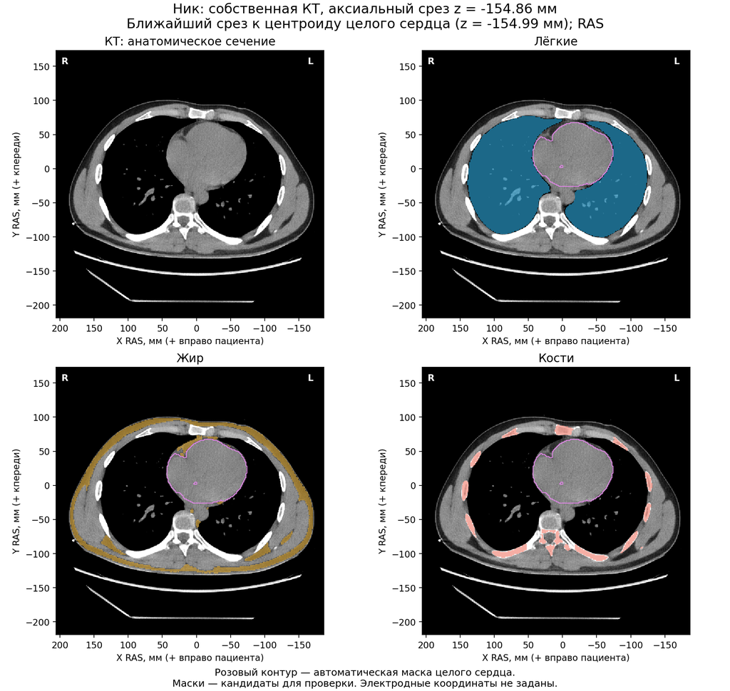

**Рисунок 23. Ник. КТ-сечение и кандидатные тканевые маски.**

Сечение выбрано по центру объёма автоматической маски сердца, а не по подгонке импеданса. Оно иллюстрирует собственную анатомию участника; положение электродов на нём пока не задано. Эти маски требуют экспертной оценки.

Как выглядят индивидуальные ткани на сечении на уровне центра маски сердца?

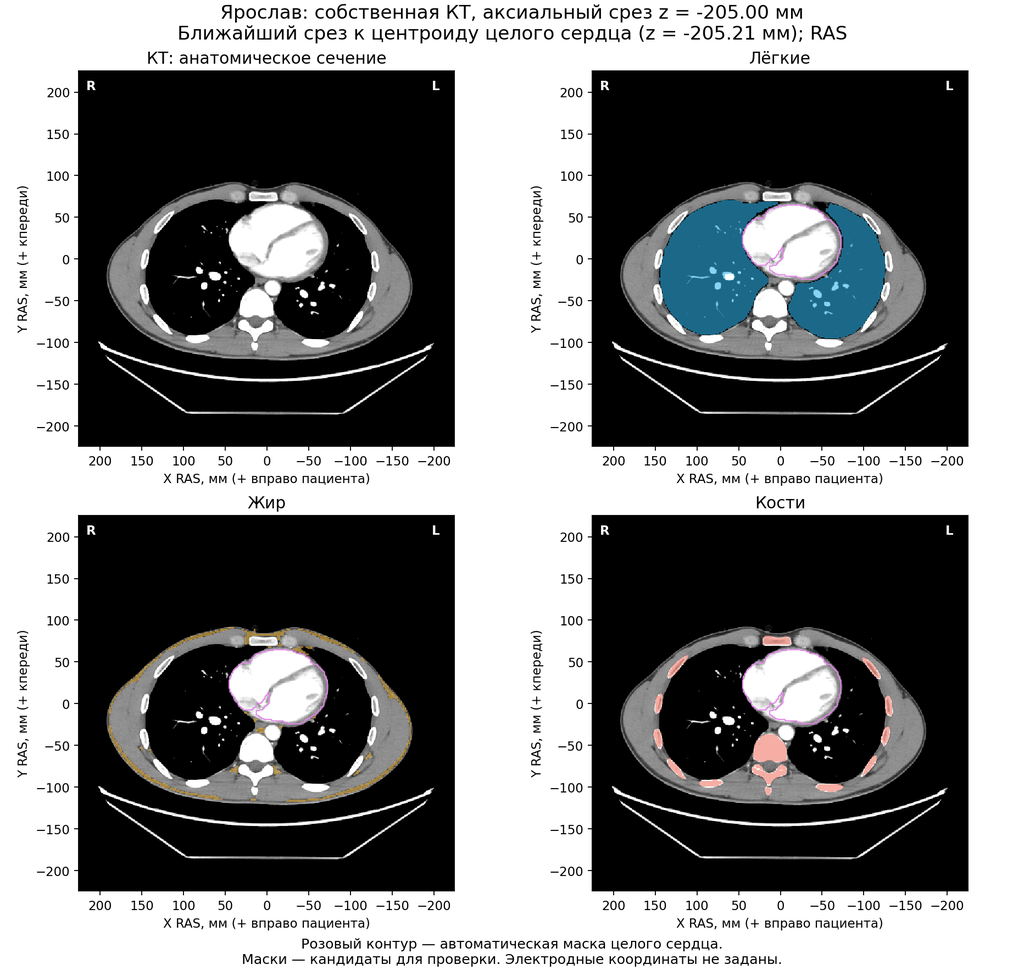

**Рисунок 24. Ярослав. КТ-сечение и кандидатные тканевые маски.**

Сечение выбрано по центру объёма автоматической маски сердца, а не по подгонке импеданса. Оно иллюстрирует собственную анатомию участника; положение электродов на нём пока не задано. Эти маски требуют экспертной оценки.

### Проверка наружного контура и примерная область установки

Входы прошли проверку согласования, но стандартная подготовка наружной поверхности **отказала у обоих участников**. Для исходной конфигурации не были обоснованы допустимые расстояния изменения контура. В отдельных диагностических пробах с иллюстративным допуском шаблона 1,25 мм выявлены топологические несоответствия воксельного контура и тканевые воксели вне него. У Ника это 2001 воксель кости и 5798 жира, у Ярослава — 3725 и 146. Максимальное выборочное изменение контура составило 1,972 и 2,500 мм. Малая ошибка экспорта поверхности и её замкнутость не отменяют эти отказы. Объёмная сетка и электрический расчёт по такому диагностическому контуру не запускались; допуски для получения положительного статуса не расширялись.

Диагностические варианты двух и трёх итераций замыкания восстановили воксельную характеристику Эйлера, но не устранили тканевые воксели снаружи и дали ещё большее смещение контура, 2,975–3,223 мм. Такие варианты стандартом не поддерживаются и не приняты. Локализация показала конкретные источники отказа: отбор крупнейшей компоненты удаляет часть верхней области; кроме того, в масках есть воксели реконструкционного заполнения DICOM, ошибочно отнесённые к ткани. Оригиналы не исправлялись. Требуются аудит анатомической области и документированные производные маски; одного положительного входного контроля недостаточно для FEM.

Чтобы отдельно проверить положение боковой сборки, построена геометрическая гипотеза на собственной КТ: высота центра соответствует центру маски сердца, переднезадняя координата — середине ширины тела на этом уровне, затем выбрана правая кожная граница с лёгким под ней. Это приближение боковой линии, а не установленная по подмышечным складкам средняя подмышечная линия. Показаны варианты ±15 мм вперёд/назад и ±20 мм по высоте; эти границы предназначены для просмотра, их погрешность измерением не установлена. Никакие координаты другого участника или подгонка импеданса здесь не использованы.

Насколько такая область соответствует фактической боковой установке?

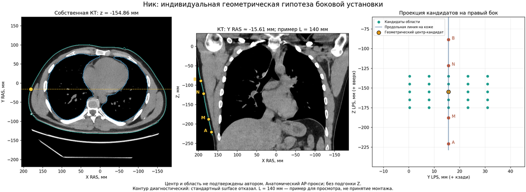

**Рисунок 25. Ник. Кандидатная боковая область на индивидуальной КТ.**

Жёлтая точка и зелёная область показывают геометрическую гипотезу центра. Пример A–M–N–B имеет длину 140 мм по кожной кривой; этот способ задания расстояний пока не подтверждает фактическую геометрию сборки. Контур диагностический, его отказ сохранён. Положение требует сверки с автором.

Насколько такая область соответствует фактической боковой установке?

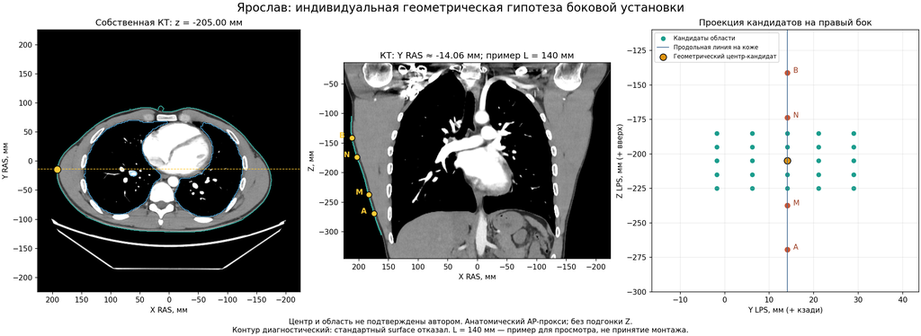

**Рисунок 26. Ярослав. Кандидатная боковая область на индивидуальной КТ.**

Жёлтая точка и зелёная область показывают геометрическую гипотезу центра. Пример A–M–N–B имеет длину 140 мм по кожной кривой; этот способ задания расстояний пока не подтверждает фактическую геометрию сборки. Контур диагностический, его отказ сохранён. Положение требует сверки с автором.

### Рабочее смещение боковой сборки и профиль тканей по КТ

24 октября 2026 года автор предложил сдвинуть сборку ещё к отрицательному Y и начать расчёты. В системе LPS это направление вперёд. Для обоих участников зафиксирован **рабочий сценарий ΔY = −15 мм относительно исходного центра**; автор не задавал численную величину. Дополнительно сопоставлены 0, −10 и −20 мм. Эти значения служат проверкой зависимости геометрии от положения и не задают измеренную ошибку установки. Для каждой плоскости Y заново выбрана наружная кожная кривая на собственной КТ; высота центра сохранена. Геометрия A–M–N–B пока задаётся длиной дуги вдоль этой кривой.

Первый расчёт определяет пространственный профиль от кожи до лёгкого. Из каждой точки кожной кривой проводится луч по положительному LPS X до первого пересечения правого лёгкого. Это одна заданная пространственная ориентация, не нормаль к коже и не направление электрической чувствительности. Кожная и лёгочная границы взяты на уровне 0,49 бинарных масок; Y и Z соответствуют собственным плоскостям вокселей. Четыре варианта положения сопоставлены на рисунке ниже.

Как смещение вперёд изменяет профиль расстояния до первого лёгкого?

[interactive chart not shown]

**Рисунок 27. Ник и Ярослав. Расстояние от кожи до первого правого лёгкого по LPS +X вдоль продольной кожной кривой при четырёх смещениях Y.**

В центре у Ника расстояние меняется с 42,875 мм при ΔY=0 до 35,984 мм при −15 мм; у Ярослава — с 48,340 до 46,582 мм. Сдвиг вперёд изменяет не только значение в центре, но и профиль по высоте. Одна центральная точка поэтому не описывает всю область сборки. Различия рассчитаны по автоматическим маскам; их сегментационная неопределённость количественно не установлена.

Затем каждый отрезок между кожей и первым лёгким пересечён с воксельными ячейками тканевых масок. Длины пересечений суммированы по тканям с приоритетом лёгкое → кость → сердце → жир → мягкотканный фон. Сумма длин проверена относительно полной длины луча. Это геометрические длины, а не электрические веса компартментов. Участок заканчивается на первом лёгком, поэтому он не показывает глубину распространения тока внутри лёгкого. Распределение тканей при выбранном смещении −15 мм показано на следующем рисунке.

Какие ткани составляют участок между кожей и первым лёгким?

[interactive chart not shown]

**Рисунок 28. Ник и Ярослав. Протяжённость тканей на лучах по LPS +X при ΔY=−15 мм. Вертикальные линии A–M–N–B обозначают пример 140 мм по кожной дуге.**

Для этого положения у обоих участников видны неоднородные участки кости и жира на фоне мягких тканей. По маскам сердца на данных коротких лучах пересечения нет; это не доказывает малую электрическую чувствительность к сердцу в полной пространственной задаче. Отсутствие лёгкого внутри отрезка связано с его определением до первого лёгкого и не означает отсутствия лёгочного вклада в импеданс.

В таблице приведён разброс длин лучей на участках трёх размеров. Для 140 мм у Ника получено 21,438–59,719 мм, у Ярослава — 29,883–73,828 мм. Это диапазоны вдоль выбранной линии, без охвата полной площади сборки или всех направлений от кожи. Медианы этих длин **не приравниваются эффективной толщине h** двуслойной модели: способ такой редукции ещё нужно определить по электрической чувствительности и проверить относительно FEM.

**Таблица 8. Расстояние до первого лёгкого вдоль боковых сборок при ΔY=−15 мм**

| Участник | Размер по дуге, мм | Лучей | Минимум, мм | Медиана, мм | Максимум, мм |
| --- | --- | --- | --- | --- | --- |
| Ник | 60 | 45 | 29.859 | 35.984 | 45.172 |
| Ник | 100 | 77 | 26.031 | 35.984 | 50.531 |
| Ник | 140 | 107 | 21.438 | 35.984 | 59.719 |
| Ярослав | 60 | 44 | 40.43 | 46.582 | 55.371 |
| Ярослав | 100 | 74 | 33.398 | 46.582 | 64.16 |
| Ярослав | 140 | 103 | 29.883 | 46.582 | 73.828 |

Профили рассчитаны, входные контрольные суммы проверены; исходные КТ и маски сохранены. **Электрический FEM-расчёт не начат:** сохраняется отказ подготовки наружной поверхности, не построены объёмная сетка и конечные CEM-площадки. Сохранённое положение передаётся как входной геометрический сценарий; оно само по себе не снимает геометрические и численные ограничения. Ранее созданные сетки Ника и Ярослава не подставлены автоматически: они имеют другие параметры рук, иной состав материалов и собственные паспорта.

## 9. Что установлено и как ограничен результат

Файловая проверка установила состав новой сессии, отсутствие байтовых дубликатов и непрерывность COUNT по модулю 256. Полное совпадение каждого TXT с BIN поддерживает единую рабочую временную шкалу. Назначение сборок у Ника и Ярослава различается, что учтено во всех расчётах и графиках.

На кандидатных задержках сравниваются три боковых размера при неизменной ТТРКГ 2×2, а вариант 1×1 рассматривается отдельно при 60 мм. Во всех основных боковых парах уровень на вдохе выше уровня на выдохе. Четыре пульсовых цикла показаны без подгонки амплитуды и длительности, а медианная форма — с явно указанным приведением к фазе QRS–QRS.

Двуслойная диагностика обнаружила зависимость найденных сопротивлений от заданной толщины, выход на численные ограничения и слабую определимость внутреннего слоя при большой h. Разные минимумы вдоха и выдоха не принимаются за анатомическую толщину. При h=120 мм пульсовая линейная инверсия не подтвердила малость возмущения; значения ρ и Δρ остаются условными.

Для Ника сопоставлены два независимых общих размера с МГТУ. Различие ТТРКГ существенно и требует отдельной проверки шкалы, монтажа и протокола. Независимого межприборного результата для Ярослава в проверенных данных нет. Индивидуальная КТ служит следующим пространственным референсом; готовность входных масок не означает готового FEM-прогноза или валидированной функции сердца. Для рабочего смещения −15 мм рассчитаны профили до первого лёгкого; они сохраняют пространственную неоднородность и пока не сведены к эффективной h.

**Воспроизведение.** Исходные TXT/BIN и КТ остаются в локальном хранилище. Инвентаризацию выполняет `audit_scorpion_session.py`, совпадения BIN — `inspect_scorpion_bin.py` и `match_scorpion_bin.py`; кандидатные окна и фильтрацию — `session_20261022.py` (владелец разметки 11.40). `session_two_layer.py` повторяет условные боковые расчёты отдельно для каждого участника; `session_equipment.py` проверяет источники МГТУ. `session_ct_geometry.py` рассчитывает геометрические профили по собственным маскам КТ и фиксирует незавершённость подготовки FEM. Данный ноутбук отображает сохранённые результаты и проверяет их происхождение, не запускает дорогие FEM-задачи. HTML содержит текст и результаты без кода; формулы могут потребовать сетевой загрузки MathJax.